# Matplotlib의 여러가지 플롯

## Imshow

화상(image) 데이터처럼 행과 열을 가진 행렬 형태의 2차원 데이터는 `imshow` 명령을 써서 2차원 자료의 크기를 색깔로 표시하는 것이다.

- http://matplotlib.org/api/pyplot_api.html#matplotlib.pyplot.imshow

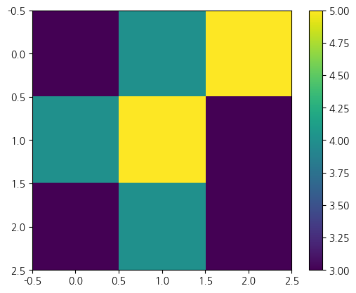

```python
# 히트맵
data_con = [[3, 4, 5], [4, 5, 3], [3, 4, 3]]
plt.imshow(data_con)
# plt.imshow(data_con, cmap='autumn')
plt.colorbar()
plt.show()
```

```python
from sklearn.datasets import load_digits
digits = load_digits()
X = digits.images[0]
X
```

```
array([[ 0.,  0.,  5., 13.,  9.,  1.,  0.,  0.],
       [ 0.,  0., 13., 15., 10., 15.,  5.,  0.],
       [ 0.,  3., 15.,  2.,  0., 11.,  8.,  0.],
       [ 0.,  4., 12.,  0.,  0.,  8.,  8.,  0.],
       [ 0.,  5.,  8.,  0.,  0.,  9.,  8.,  0.],
       [ 0.,  4., 11.,  0.,  1., 12.,  7.,  0.],
       [ 0.,  2., 14.,  5., 10., 12.,  0.,  0.],
       [ 0.,  0.,  6., 13., 10.,  0.,  0.,  0.]])
```

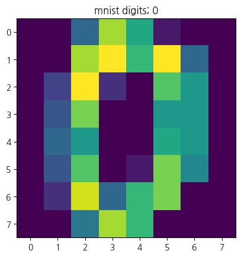

```python
plt.title("mnist digits; 0")
plt.imshow(X, interpolation='nearest')

# plt.subplots_adjust(left=0.35, right=0.65, bottom=0.35, top=0.65)
plt.show()
```

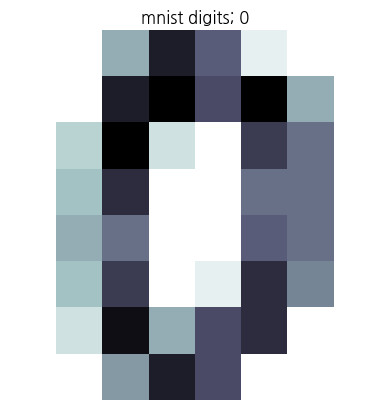

```python
plt.title("mnist digits; 0")
plt.imshow(X, interpolation='nearest', cmap=plt.cm.bone_r)

plt.xticks([]) # ticks 숨기기
plt.yticks([])
# plt.axis('off')

# plt.subplots_adjust(left=0.35, right=0.65, bottom=0.35, top=0.65)
plt.show()
```

데이터 수치를 색으로 바꾸는 함수는 칼라맵(color map)이라고 한다. 칼라맵은 `cmap` 인수로 지정한다.  
사용할 수 있는 칼라맵은 `plt.cm`의 속성으로 포함되어 있다. 아래에 일부 칼라맵을 표시하였다.  
칼라맵은 문자열로 지정해도 된다. 칼라맵에 대한 자세한 내용은 다음 웹사이트를 참조한다.

- https://matplotlib.org/tutorials/colors/colormaps.html

```python
dir(plt.cm)[:10]
```

```
['Accent',
 'Accent_r',
 'Blues',
 'Blues_r',
 'BrBG',
 'BrBG_r',
 'BuGn',
 'BuGn_r',
 'BuPu',
 'BuPu_r']
```

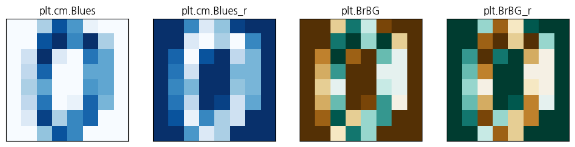

```python
fig, axes = plt.subplots(1, 4, figsize=(12, 3), subplot_kw={'xticks': [], 'yticks': []})

axes[0].set_title("plt.cm.Blues")
axes[0].imshow(X, interpolation='nearest', cmap=plt.cm.Blues)

axes[1].set_title("plt.cm.Blues_r")
axes[1].imshow(X, interpolation='nearest', cmap=plt.cm.Blues_r)

axes[2].set_title("plt.BrBG")
axes[2].imshow(X, interpolation='nearest', cmap='BrBG')

axes[3].set_title("plt.BrBG_r")
axes[3].imshow(X, interpolation='nearest', cmap='BrBG_r')
plt.show()
```

`imshow` 명령은 자료의 시각화를 돕기위해 다양한 2차원 인터폴레이션을 지원한다.

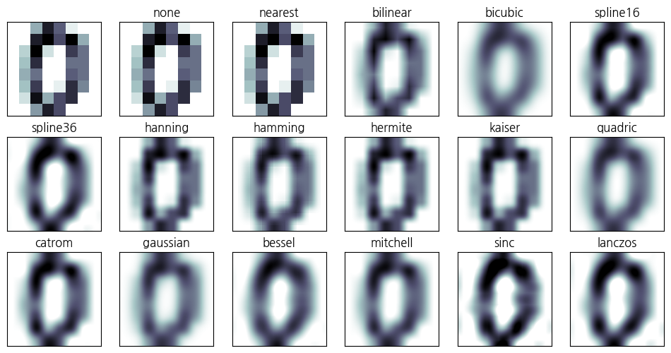

```python
methods = [
    None, 'none', 'nearest', 'bilinear', 'bicubic', 'spline16',
    'spline36', 'hanning', 'hamming', 'hermite', 'kaiser', 'quadric',
    'catrom', 'gaussian', 'bessel', 'mitchell', 'sinc', 'lanczos'
]

fig, axes = plt.subplots(3, 6, figsize=(12, 6), subplot_kw={'xticks': [], 'yticks': []})


for ax, interp_method in zip(axes.flat, methods):
    ax.imshow(X, cmap=plt.cm.bone_r, interpolation=interp_method)
    ax.set_title(interp_method)


plt.show()
```

```python
# axes.flat : 배열에 대한 1차원 반복기
# 배열에 대한 이터레이터이기 때문에 3X2축 배열의 모든 축을 반복할 수 있다.
# 아래처럼 고차원 배열의 값을 뽑으려면 고차원의 포문으로 뽑아야 함.

import numpy as np

a = np.array([[2,3],
              [4,5],
              [6,7]])

for i in a.flat:
    print(i)
```

```
2
3
4
5
6
7
```

## 컨투어 플롯

입력 변수가 x, y 두 개이고 출력 변수가 z 하나인 경우에는 3차원 자료가 된다.  
3차원 자료를 시각화하는 방법은 명암이 아닌 등고선(contour)을 사용하는 방법이다.  
`contour` 혹은 `contourf` 명령을 사용한다. `contour`는 등고선만 표시하고 `contourf`는 색깔로 표시한다.  
입력 변수 x, y는 그대로 사용할 수 없고 `meshgrid` 명령으로 그리드 포인트 행렬을 만들어야 한다.  
더 자세한 내용은 다음 웹사이트를 참조한다.

- http://matplotlib.org/api/pyplot_api.html#matplotlib.pyplot.contour
- http://matplotlib.org/api/pyplot_api.html#matplotlib.pyplot.contourf

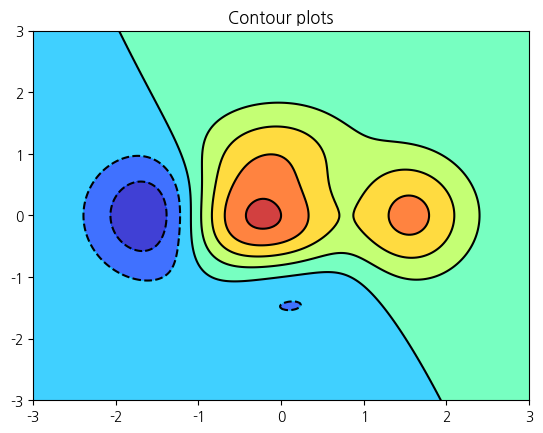

```python
def f(x, y): # z값 계산 합수
    return (1 - (x/2) + (x**5) + (y**3)) * np.exp(-x**2 - y**2)

n = 256
x = np.linspace(-3, 3, n)
y = np.linspace(-3, 3, n)

XX, YY = np.meshgrid(x, y) # 그리드 포인트 행렬값으로 변환
ZZ = f(XX, YY) # z값 계산

plt.title("Contour plots")
plt.contourf(XX, YY, ZZ, alpha=.75, cmap='jet') # 색깔로 표시
plt.contour(XX, YY, ZZ, colors='black') # 등고선만 표시
plt.show()
```

## 3D 서피스 플롯

3차원 플롯은 등고선 플롯과 달리 Axes3D라는 3차원 전용 axes를 생성하여 입체적으로 표시한다.

plot_surface 명령을 사용한다.

- http://matplotlib.org/mpl_toolkits/mplot3d/api.html#mpl_toolkits.mplot3d.axes3d.Axes3D.plot_surface
- https://lifelong-education-dr-kim.tistory.com/entry/3%EC%B0%A8%EC%9B%90%EC%9D%98-%ED%91%9C%EB%A9%B4%EC%9D%84-%EC%83%9D%EC%84%B1%EC%9D%84-%EC%9C%84%ED%95%9C-matplotlib%EC%9D%98-plotsurface-%ED%95%A8%EC%88%98
- https://codetorial.net/matplotlib/3d_plot_surface.html

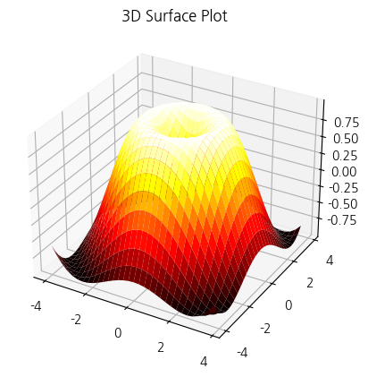

```python
# matplotlib 3.2.0부터 axes3d를 명시적으로 임포트 하지 않아도 됨
# from mpl_toolkits.mplot3d import Axes3D
X = np.arange(-4, 4, 0.25)
Y = np.arange(-4, 4, 0.25)
XX, YY = np.meshgrid(X, Y)
ZZ = np.sin(np.sqrt(XX**2 + YY**2))


fig = plt.figure()
# ax = Axes3D(fig)
ax = fig.add_subplot(111, projection='3d')
ax.set_title("3D Surface Plot")

ax.plot_surface(XX, YY, ZZ, rstride=1, cstride=1, cmap='hot')
plt.show()
```

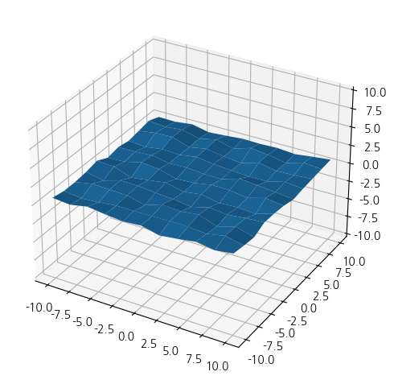

```python
# from mpl_toolkits.mplot3d import axes3d
# import matplotlib.pyplot as plt
# import numpy as np

fig, ax = plt.subplots(subplot_kw={"projection": "3d"})
#fig = plt.figure()
#ax = fig.add_subplot(111, projection='3d')

x = np.linspace(-10, 10, 11)
X = np.tile(x, (11, 1))
Y = np.transpose(X)
Z = np.random.rand(11, 11)

ax.plot_surface(X, Y, Z)
ax.set_zlim(-10, 10)

plt.tight_layout()
plt.show()
```

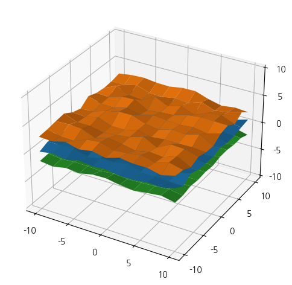

```python
# 축 는금 지정하기
#  세 개의 2차원 어레이를 3차원 Surface로 표현했습니다.

fig = plt.figure()
ax = fig.add_subplot(111, projection='3d')

x = np.linspace(-10, 10, 11)
X = np.tile(x, (11, 1))
Y = np.transpose(X)
Z = np.random.rand(11, 11)
Z2 = 1.5 * np.random.rand(11, 11) + 2
Z3 = np.random.rand(11, 11) - 2

ax.plot_surface(X, Y, Z)
ax.plot_surface(X, Y, Z2)
ax.plot_surface(X, Y, Z3)
ax.set_zlim(-10, 10)

# set_xticks(), set_yticks(), set_zticks()는 X, Y, Z축의 눈금의 위치를 지정합니다.
ax.set_xticks([-10, -5, 0, 5, 10])
ax.set_yticks([-10, -5, 0, 5, 10])
ax.set_zticks([-10, -5, 0, 5, 10])

plt.tight_layout()
plt.show()
```

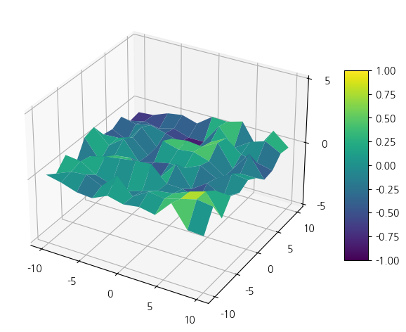

```python
# 컬러맵, 컬러바 사용하기

fig = plt.figure()
ax = fig.add_subplot(111, projection='3d')

x = np.linspace(-10, 10, 11)
X = np.tile(x, (11, 1))
Y = np.transpose(X)
Z = 2 * np.random.rand(11, 11) - 1

surf = ax.plot_surface(X, Y, Z, cmap='viridis') # plot_surface() 함수의 cmap은 3차원 Surface의 컬러맵을 지정합니다.

ax.set_zlim(-5, 5)
ax.set_xticks([-10, -5, 0, 5, 10])
ax.set_yticks([-10, -5, 0, 5, 10])
ax.set_zticks([-5, 0, 5])

fig.colorbar(surf, shrink=0.6, aspect=8) # colorbar()를 호출하면 그래프에 컬러바를 표시합니다.
# shrink는 컬러바의 크기, aspect는 컬러바의 종횡비를 지정합니다.

surf.set_clim(-1.0, 1.0)
plt.tight_layout()
plt.show()
```